# Project: Investigate a Dataset - [tmdb-movies.csv]

- Introduction
- Data Wrangling
- Exploratory Data Analysis
- Conclusions

## Introduction

### Dataset Description

> This data set contains information about 10,000 movies collected from The Movie Database (TMDb), including user ratings and revenue.
> - Certain columns, like ‘cast’ and ‘genres’, contain multiple values separated by pipe (|) characters.
> - The final two columns ending with “_adj” show the budget and revenue of the associated movie in terms of 2010 dollars, accounting for inflation over time.

### Question(s) for Analysis

#### Question No 1 : are the Run times of movies changes over the time ?

#### Question No 2 : what are the Longest and shortest Movies ?

#### Question No 3 : what is the year with most number of movies releases ?

#### Question No 4 : What are the movies with heighest and lowest profit ?

#### Question No 5: which movie has the most voting counts ?

#### Question No 6: what are the most popular genre over the years?

#### Question No 7: who are the top 10 directors with the most number of movies ?

#### Question No 8: what are the Top 10 Production compines with the most number of movies ?

#### Question No 9: what are the Top 10 Profitable Movies ?

```python
# Use this cell to set up import statements for all of the packages that you
#   plan to use.
import numpy as np
import pandas as pd
import matplotlib.pyplot as plt
import seaborn as sns

# Remember to include a 'magic word' so that your visualizations are plotted
#   inline with the notebook. See this page for more:
#   http://ipython.readthedocs.io/en/stable/interactive/magics.html
% matplotlib inline
```

## Data Wrangling

> In this section of the report, load in the data, check for cleanliness, and then trim and clean the dataset for analysis.

```python
# Load your data and print out a few lines. Perform operations to inspect data
#   types and look for instances of missing or possibly errant data.
df=pd.read_csv('tmdb-movies.csv')
df.head()
```

|  | id | imdb_id | popularity | budget | revenue | original_title | cast | homepage | director | tagline | ... | overview | runtime | genres | production_companies | release_date | vote_count | vote_average | release_year | budget_adj | revenue_adj |
| --- | --- | --- | --- | --- | --- | --- | --- | --- | --- | --- | --- | --- | --- | --- | --- | --- | --- | --- | --- | --- | --- |
| 0 | 135397 | tt0369610 | 32.985763 | 150000000 | 1513528810 | Jurassic World | Chris Pratt\|Bryce Dallas Howard\|Irrfan Khan\|Vi... | http://www.jurassicworld.com/ | Colin Trevorrow | The park is open. | ... | Twenty-two years after the events of Jurassic ... | 124 | Action\|Adventure\|Science Fiction\|Thriller | Universal Studios\|Amblin Entertainment\|Legenda... | 6/9/15 | 5562 | 6.5 | 2015 | 1.379999e+08 | 1.392446e+09 |
| 1 | 76341 | tt1392190 | 28.419936 | 150000000 | 378436354 | Mad Max: Fury Road | Tom Hardy\|Charlize Theron\|Hugh Keays-Byrne\|Nic... | http://www.madmaxmovie.com/ | George Miller | What a Lovely Day. | ... | An apocalyptic story set in the furthest reach... | 120 | Action\|Adventure\|Science Fiction\|Thriller | Village Roadshow Pictures\|Kennedy Miller Produ... | 5/13/15 | 6185 | 7.1 | 2015 | 1.379999e+08 | 3.481613e+08 |
| 2 | 262500 | tt2908446 | 13.112507 | 110000000 | 295238201 | Insurgent | Shailene Woodley\|Theo James\|Kate Winslet\|Ansel... | http://www.thedivergentseries.movie/#insurgent | Robert Schwentke | One Choice Can Destroy You | ... | Beatrice Prior must confront her inner demons ... | 119 | Adventure\|Science Fiction\|Thriller | Summit Entertainment\|Mandeville Films\|Red Wago... | 3/18/15 | 2480 | 6.3 | 2015 | 1.012000e+08 | 2.716190e+08 |
| 3 | 140607 | tt2488496 | 11.173104 | 200000000 | 2068178225 | Star Wars: The Force Awakens | Harrison Ford\|Mark Hamill\|Carrie Fisher\|Adam D... | http://www.starwars.com/films/star-wars-episod... | J.J. Abrams | Every generation has a story. | ... | Thirty years after defeating the Galactic Empi... | 136 | Action\|Adventure\|Science Fiction\|Fantasy | Lucasfilm\|Truenorth Productions\|Bad Robot | 12/15/15 | 5292 | 7.5 | 2015 | 1.839999e+08 | 1.902723e+09 |
| 4 | 168259 | tt2820852 | 9.335014 | 190000000 | 1506249360 | Furious 7 | Vin Diesel\|Paul Walker\|Jason Statham\|Michelle ... | http://www.furious7.com/ | James Wan | Vengeance Hits Home | ... | Deckard Shaw seeks revenge against Dominic Tor... | 137 | Action\|Crime\|Thriller | Universal Pictures\|Original Film\|Media Rights ... | 4/1/15 | 2947 | 7.3 | 2015 | 1.747999e+08 | 1.385749e+09 |

5 rows × 21 columns

### Data Cleaning

```python
# the dimensions of the dataframe
df.shape
```

```
(10866, 21)
```

```python
# the datatypes of the columns
df.dtypes
```

```
id                        int64
imdb_id                  object
popularity              float64
budget                    int64
revenue                   int64
original_title           object
cast                     object
homepage                 object
director                 object
tagline                  object
keywords                 object
overview                 object
runtime                   int64
genres                   object
production_companies     object
release_date             object
vote_count                int64
vote_average            float64
release_year              int64
budget_adj              float64
revenue_adj             float64
dtype: object
```

```python
# although the datatype for imdb_id appears to be object, further investigation shows it's a string
type(df['imdb_id'][0])
```

```
str
```

```python
# although the datatype for original_title appears to be object, further investigation shows it's a string
type(df['original_title'][0])
```

```
str
```

#### Concalusion: Pandas actually stores pointers to strings in dataframes and series, which is why object instead of str appears as the datatype. so that strings will appear as objects in Pandas.

```python
# summary of the dataframe,including the number of non-null values in each column
df.info()
```

```
<class 'pandas.core.frame.DataFrame'>
RangeIndex: 10866 entries, 0 to 10865
Data columns (total 21 columns):
id                      10866 non-null int64
imdb_id                 10856 non-null object
popularity              10866 non-null float64
budget                  10866 non-null int64
revenue                 10866 non-null int64
original_title          10866 non-null object
cast                    10790 non-null object
homepage                2936 non-null object
director                10822 non-null object
tagline                 8042 non-null object
keywords                9373 non-null object
overview                10862 non-null object
runtime                 10866 non-null int64
genres                  10843 non-null object
production_companies    9836 non-null object
release_date            10866 non-null object
vote_count              10866 non-null int64
vote_average            10866 non-null float64
release_year            10866 non-null int64
budget_adj              10866 non-null float64
revenue_adj             10866 non-null float64
dtypes: float64(4), int64(6), object(11)
memory usage: 1.7+ MB
```

```python
# the number of unique values in each column
df.nunique()
```

```
id                      10865
imdb_id                 10855
popularity              10814
budget                    557
revenue                  4702
original_title          10571
cast                    10719
homepage                 2896
director                 5067
tagline                  7997
keywords                 8804
overview                10847
runtime                   247
genres                   2039
production_companies     7445
release_date             5909
vote_count               1289
vote_average               72
release_year               56
budget_adj               2614
revenue_adj              4840
dtype: int64
```

```python
# using means to fill in missing values
df.fillna(df.mean(), inplace=True)
# confirm correction with info()
df.info()
```

```
<class 'pandas.core.frame.DataFrame'>
RangeIndex: 10866 entries, 0 to 10865
Data columns (total 21 columns):
id                      10866 non-null int64
imdb_id                 10856 non-null object
popularity              10866 non-null float64
budget                  10866 non-null int64
revenue                 10866 non-null int64
original_title          10866 non-null object
cast                    10790 non-null object
homepage                2936 non-null object
director                10822 non-null object
tagline                 8042 non-null object
keywords                9373 non-null object
overview                10862 non-null object
runtime                 10866 non-null int64
genres                  10843 non-null object
production_companies    9836 non-null object
release_date            10866 non-null object
vote_count              10866 non-null int64
vote_average            10866 non-null float64
release_year            10866 non-null int64
budget_adj              10866 non-null float64
revenue_adj             10866 non-null float64
dtypes: float64(4), int64(6), object(11)
memory usage: 1.7+ MB
```

```python
# check for duplicates in the data
sum(df.duplicated())
```

```
1
```

```python
# drop duplicates
df.drop_duplicates(inplace=True)
# confirm correction by rechecking for duplicates in the data
sum(df.duplicated())
```

```
0
```

```python
df.nunique()
```

```
id                      10865
imdb_id                 10855
popularity              10814
budget                    557
revenue                  4702
original_title          10571
cast                    10719
homepage                 2896
director                 5067
tagline                  7997
keywords                 8804
overview                10847
runtime                   247
genres                   2039
production_companies     7445
release_date             5909
vote_count               1289
vote_average               72
release_year               56
budget_adj               2614
revenue_adj              4840
dtype: int64
```

```python
df=df.drop(columns = ['homepage','imdb_id','cast','tagline','budget_adj','revenue_adj'])
df.describe()
```

|  | id | popularity | budget | revenue | runtime | vote_count | vote_average | release_year |
| --- | --- | --- | --- | --- | --- | --- | --- | --- |
| count | 10865.000000 | 10865.000000 | 1.086500e+04 | 1.086500e+04 | 10865.000000 | 10865.000000 | 10865.000000 | 10865.000000 |
| mean | 66066.374413 | 0.646446 | 1.462429e+07 | 3.982690e+07 | 102.071790 | 217.399632 | 5.975012 | 2001.321859 |
| std | 92134.091971 | 1.000231 | 3.091428e+07 | 1.170083e+08 | 31.382701 | 575.644627 | 0.935138 | 12.813260 |
| min | 5.000000 | 0.000065 | 0.000000e+00 | 0.000000e+00 | 0.000000 | 10.000000 | 1.500000 | 1960.000000 |
| 25% | 10596.000000 | 0.207575 | 0.000000e+00 | 0.000000e+00 | 90.000000 | 17.000000 | 5.400000 | 1995.000000 |
| 50% | 20662.000000 | 0.383831 | 0.000000e+00 | 0.000000e+00 | 99.000000 | 38.000000 | 6.000000 | 2006.000000 |
| 75% | 75612.000000 | 0.713857 | 1.500000e+07 | 2.400000e+07 | 111.000000 | 146.000000 | 6.600000 | 2011.000000 |
| max | 417859.000000 | 32.985763 | 4.250000e+08 | 2.781506e+09 | 900.000000 | 9767.000000 | 9.200000 | 2015.000000 |

```python
print("Number of Rows",df.shape[0])
print("Number of columns",df.shape[1])
```

```
Number of Rows 10865
Number of columns 15
```

```python
#check any missing values
df.isnull().values.any()
```

```
True
```

```python
df.isnull().sum()
```

```
id                         0
popularity                 0
budget                     0
revenue                    0
original_title             0
director                  44
keywords                1493
overview                   4
runtime                    0
genres                    23
production_companies    1030
release_date               0
vote_count                 0
vote_average               0
release_year               0
dtype: int64
```

```python
#check duplicted values
df.duplicated().any()
```

```
False
```

## Exploratory Data Analysis

> Investigate the stated question(s) from multiple angles.

### Research Question 1 Are the Run times of movies changes over the time ?

```python
# Run times of movies > 60 minutes = 1 hour
df=df[df['runtime']>60]
df.describe()
```

|  | id | popularity | budget | revenue | runtime | vote_count | vote_average | release_year |
| --- | --- | --- | --- | --- | --- | --- | --- | --- |
| count | 10523.000000 | 10523.000000 | 1.052300e+04 | 1.052300e+04 | 10523.000000 | 10523.000000 | 10523.000000 | 10523.000000 |
| mean | 64355.978238 | 0.657025 | 1.509127e+07 | 4.111128e+07 | 104.647154 | 223.014445 | 5.952979 | 2001.177421 |
| std | 90822.024197 | 1.010064 | 3.129663e+07 | 1.186715e+08 | 28.160531 | 583.950315 | 0.928515 | 12.829692 |
| min | 5.000000 | 0.000065 | 0.000000e+00 | 0.000000e+00 | 61.000000 | 10.000000 | 1.500000 | 1960.000000 |
| 25% | 10478.500000 | 0.212056 | 0.000000e+00 | 0.000000e+00 | 91.000000 | 17.000000 | 5.400000 | 1994.000000 |
| 50% | 19855.000000 | 0.389170 | 0.000000e+00 | 0.000000e+00 | 99.000000 | 39.000000 | 6.000000 | 2005.000000 |
| 75% | 72389.000000 | 0.725521 | 1.700000e+07 | 2.630940e+07 | 112.000000 | 152.000000 | 6.600000 | 2011.000000 |
| max | 417859.000000 | 32.985763 | 4.250000e+08 | 2.781506e+09 | 900.000000 | 9767.000000 | 9.200000 | 2015.000000 |

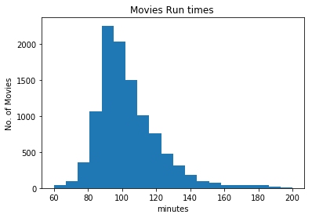

```python
#histogram to explain the changes of movies run times over the time
plt.hist(df['runtime'],range=(60,200) , bins = 20)
plt.title('Movies Run times ')
plt.xlabel('minutes')
plt.ylabel('No. of Movies')
plt.show()
```

## we can see that the most of the movies runtime between 85 to 120 minutes

```python
# Avg movies runtimes over the years
movies_group=df['runtime'].groupby(df['release_year']).describe()
avg_runtime_by_year = movies_group['mean']
avg_runtime_min = movies_group['mean'] - movies_group['std']
avg_runtime_max = movies_group['mean'] + movies_group['std']
```

```python
print (avg_runtime_by_year)
```

```
release_year
1960    110.656250
1961    119.419355
1962    124.343750
1963    114.151515
1964    112.675000
1965    120.911765
1966    112.581395
1967    108.921053
1968    115.250000
1969    113.000000
1970    113.650000
1971    107.727273
1972    101.950000
1973    104.981481
```

[output cut: 43 more lines]

```python
print (avg_runtime_min)
```

```
release_year
1960    77.164210
1961    91.251082
1962    88.037162
1963    80.324639
1964    91.274799
1965    89.556162
1966    87.832915
1967    89.971074
1968    93.588480
1969    90.419984
1970    83.318033
1971    86.448302
1972    82.283616
1973    90.190497
```

[output cut: 43 more lines]

```python
print (avg_runtime_max)
```

```
release_year
1960    144.148290
1961    147.587628
1962    160.650338
1963    147.978392
1964    134.075201
1965    152.267367
1966    137.329875
1967    127.871032
1968    136.911520
1969    135.580016
1970    143.981967
1971    129.006244
1972    121.616384
1973    119.772466
```

[output cut: 43 more lines]

### Research Question 2 what are the Longest and shortest Movies ?

```python
print(df.original_title[df.runtime == df.runtime.max()])
print(df.runtime[df.runtime == df.runtime.max()])
```

```
3894    The Story of Film: An Odyssey
Name: original_title, dtype: object
3894    900
Name: runtime, dtype: int64
```

#### the longest Moive : [The Story of Film: An Odyssey] with runtimes 900 Minutes

```python
print(df.original_title[df.runtime == df.runtime.min()])
print(df.runtime[df.runtime == df.runtime.min()])
```

```
1683                            Ju-on: Shiroi rÃ´jo
4906             Aziz Ansari: Dangerously Delicious
7798    Zach Galifianakis: Live at the Purple Onion
8370                         Bill Hicks: Relentless
Name: original_title, dtype: object
1683    61
4906    61
7798    61
8370    61
Name: runtime, dtype: int64
```

#### the shortest movies with runtimes 61 minutes:

- Ju-on: Shiroi rÃ´jo
- Aziz Ansari: Dangerously Delicious
- Zach Galifianakis: Live at the Purple Onion
- Bill Hicks: Relentless

### Research Question 3 what is the year with most number of movies releases ?

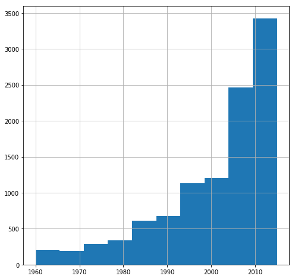

```python
df['release_year'].hist(figsize=(8,8));
```

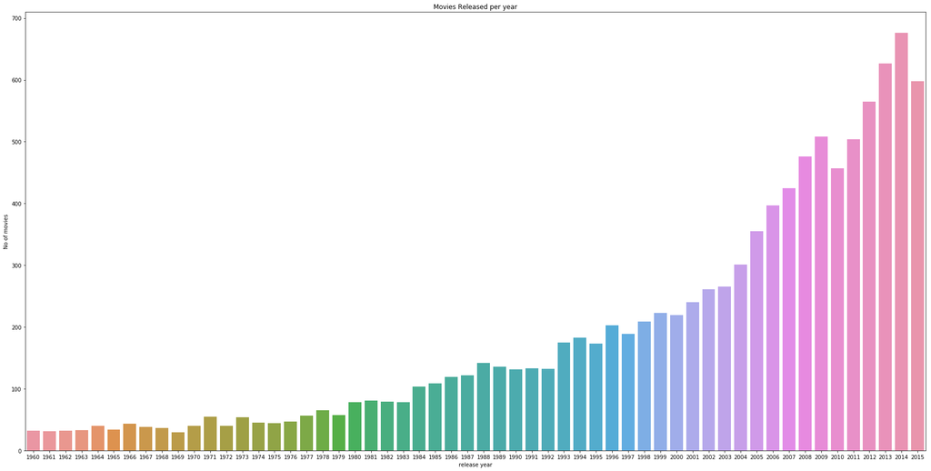

```python
plt.figure(figsize=(30,15))
sns.countplot(df['release_year'])
plt.title('Movies Released per year')
plt.xlabel('release year')
plt.ylabel('No of movies')
plt.show()
```

#### 2014 is the Most year have the Movies releases about 680 Moives releases

### Research Question 4 What are the movies with heighest and lowest profit ?

> **Tip**: PROFIT = REVENUE - BUDGET so i will creat nwe col with name " PROFIT" by the above equation

```python
#creation Profit Col.
df['Profit'] = df['revenue'] - df['budget']
df.describe()
```

|  | id | popularity | budget | revenue | runtime | vote_count | vote_average | release_year | Profit |
| --- | --- | --- | --- | --- | --- | --- | --- | --- | --- |
| count | 10523.000000 | 10523.000000 | 1.052300e+04 | 1.052300e+04 | 10523.000000 | 10523.000000 | 10523.000000 | 10523.000000 | 1.052300e+04 |
| mean | 64355.978238 | 0.657025 | 1.509127e+07 | 4.111128e+07 | 104.647154 | 223.014445 | 5.952979 | 2001.177421 | 2.602001e+07 |
| std | 90822.024197 | 1.010064 | 3.129663e+07 | 1.186715e+08 | 28.160531 | 583.950315 | 0.928515 | 12.829692 | 9.803524e+07 |
| min | 5.000000 | 0.000065 | 0.000000e+00 | 0.000000e+00 | 61.000000 | 10.000000 | 1.500000 | 1960.000000 | -4.139124e+08 |
| 25% | 10478.500000 | 0.212056 | 0.000000e+00 | 0.000000e+00 | 91.000000 | 17.000000 | 5.400000 | 1994.000000 | 0.000000e+00 |
| 50% | 19855.000000 | 0.389170 | 0.000000e+00 | 0.000000e+00 | 99.000000 | 39.000000 | 6.000000 | 2005.000000 | 0.000000e+00 |
| 75% | 72389.000000 | 0.725521 | 1.700000e+07 | 2.630940e+07 | 112.000000 | 152.000000 | 6.600000 | 2011.000000 | 1.100000e+07 |
| max | 417859.000000 | 32.985763 | 4.250000e+08 | 2.781506e+09 | 900.000000 | 9767.000000 | 9.200000 | 2015.000000 | 2.544506e+09 |

```python
# the Max Profit Movies
print(df.original_title[df['Profit']==df['Profit'].max()])
```

```
1386    Avatar
Name: original_title, dtype: object
```

```python
# the Min Profit Movies
print(df.original_title[df['Profit']==df['Profit'].min()])
```

```
2244    The Warrior's Way
Name: original_title, dtype: object
```

#### The Max Profit Movie is Avatar

#### The Min Profit Movie is The Warrior's Way

### Research Question 5 which movie has the most voting counts ?

```python
#the movie which has the most voting counts
print(df.original_title[df['vote_count']==df['vote_count'].max()])
```

```
1919    Inception
Name: original_title, dtype: object
```

#### INCEPTION MOVIE has the most voting counts

### Research Question 6 what are the most popular genre over the years?

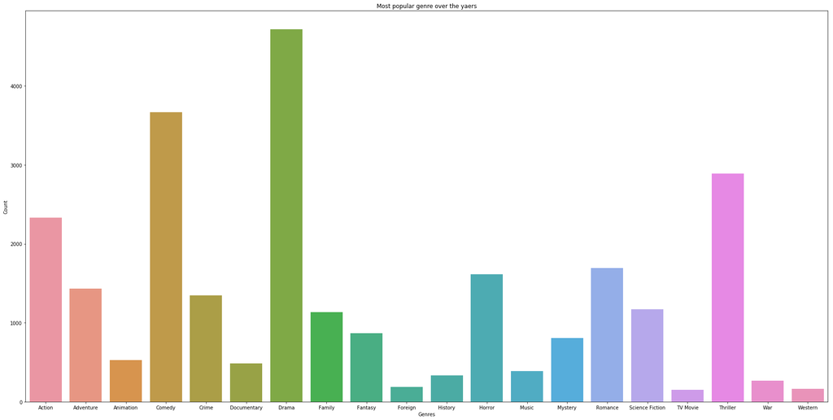

```python
# Creat genres sum
genres = df['genres'].str.get_dummies(sep='|')
genres_sum = df['genres'].str.get_dummies(sep='|').sum().reset_index()
# Plot most popluar genres sum over the years
plt.figure(figsize=(30,15))
sns.barplot(x=genres.columns, y=genres.sum(), data= genres_sum)
plt.title('Most popular genre over the yaers')
plt.xlabel('Genres')
plt.ylabel('Count')
plt.show()
```

#### the most generes over the years are:

- DARAMA
- COMEDY
- THRILLER
- ACTION
- ROMANCE
- HORROR
- ADVENTURE

### Research Question 7 who are the top 10 directors with the most number of movies ?

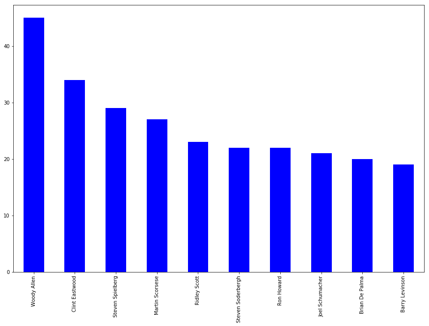

```python
df['director'].value_counts().head(10).plot.bar(figsize=(15,10), color = 'blue')
plt.show()
```

#### TOP 10 Directors as shown

- WOODY ALLEN
- CLINT EASTWOOD
- STEVEN SPIELBERG
- MARTIN SCARSESE
- RIDLEY SCOTT
- STEVEN SODERBERGH
- RON HOWARD
- JOEL SCHUMACHER
- BRIAN DE PALMA
- Barry LEVINSON

### Research Question 8 what are the Top 10 Production compines with the most number of movies ?

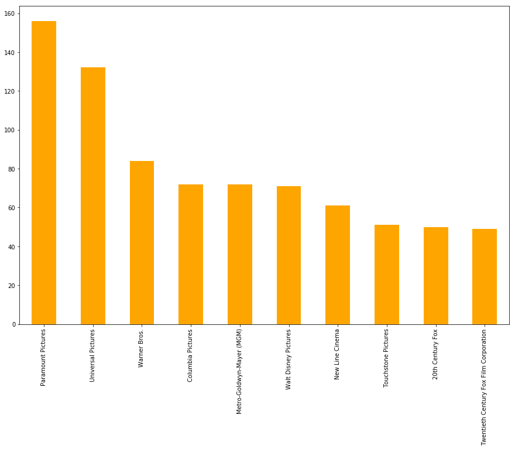

```python
df['production_companies'].value_counts().head(10).plot.bar(figsize=(15,10), color = 'orange')
plt.show()
```

#### TOP 10 Production Compaines as shown

- PARAMOUNT PICTURES
- UNIVERSAL PICTURES
- WARNER BROS
- COLUMBIA PICTURES
- M-G-M
- WALT DISNEY
- NEW LINE
- TOUCHSTONE PICTURES
- 20th Century FOX
- 20 th century fox film Corporation

### Research Question 9 what are the Top 10 Profitable Movies ?

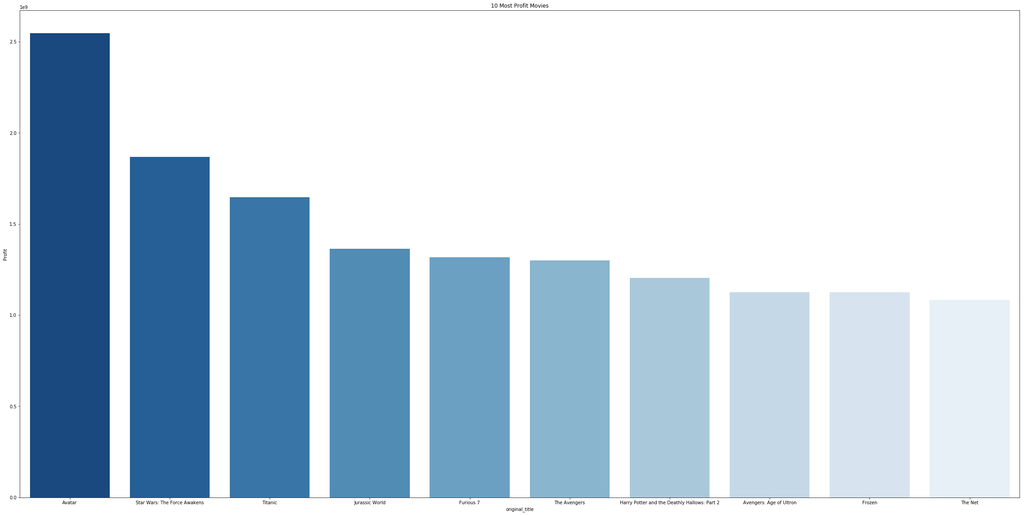

```python
#the top 10 Most Profit Movies
plt.figure(figsize=(40,20))
top_profit = df[['original_title','Profit']].sort_values('Profit', ascending = False).head(10)
sns.barplot(x='original_title', y='Profit', data=top_profit, palette='Blues_r')
plt.xlabel('original_title')
plt.ylabel('Profit')
plt.title('10 Most Profit Movies')
plt.show()
```

## Conclusions

> **2**: the longest Moive : [The Story of Film: An Odyssey] with runtimes 900 Minutes and the shortest movies with runtimes 61 minutes are:
> - Ju-on: Shiroi rÃ´jo
> - Aziz Ansari: Dangerously Delicious
> - Zach Galifianakis: Live at the Purple Onion
> - Bill Hicks: Relentless

> **3**: 2014 is the Most year have the Movies releases about 680 Moives releases

> **4**: The Max Profit Movie is Avatar & The Min Profit Movie is The Warrior's Way

> **5**: INCEPTION MOVIE has the most voting counts

> **6**: the most generes over the years are:
> - DARAMA
> - COMEDY
> - THRILLER
> - ACTION
> - ROMANCE
> - HORROR
> - ADVENTURE

> **7**: TOP 10 Directors as shown
> - WOODY ALLEN
> - CLINT EASTWOOD
> - STEVEN SPIELBERG
> - MARTIN SCARSESE
> - RIDLEY SCOTT
> - STEVEN SODERBERGH
> - RON HOWARD
> - JOEL SCHUMACHER
> - BRIAN DE PALMA
> - Barry LEVINSON

> **8**: TOP 10 Production Compaines as shown
> - PARAMOUNT PICTURES
> - UNIVERSAL PICTURES
> - WARNER BROS
> - COLUMBIA PICTURES
> - M-G-M
> - WALT DISNEY
> - NEW LINE
> - TOUCHSTONE PICTURES
> - 20th Century FOX
> - 20 th century fox film Corporation

```python
from subprocess import call
call(['python', '-m', 'nbconvert', 'Investigate_a_Dataset.ipynb'])
```

```
0
```